# 0 - EDA

```python
import numpy as np
import pandas as pd
from matplotlib import pyplot as plt
import seaborn as sns
```

```python
sns.set(style="ticks", color_codes=True)
```

```python
%matplotlib inline
```

```python
%load_ext autoreload
%autoreload 2
```

```python
# Sklearn imports
from sklearn.preprocessing import Imputer
from sklearn.preprocessing import StandardScaler, LabelBinarizer, LabelEncoder, OneHotEncoder
from sklearn.decomposition import PCA
from sklearn.linear_model import LogisticRegression
from sklearn.pipeline import Pipeline
from sklearn.model_selection import cross_val_score, KFold, ShuffleSplit, StratifiedKFold, StratifiedShuffleSplit, train_test_split
from sklearn.metrics import confusion_matrix, f1_score, accuracy_score
```

```python
import helperFunctions
```

```python
# Setting the random state for later use
random_state = 565
```

# Load Dataset

```python
df = pd.read_csv('training.csv', delimiter=';')
```

```python
df.head(10)
```

|  | v1 | v2 | v3 | v4 | v5 | v6 | v7 | v8 | v9 | v10 | v11 | v12 | v13 | v14 | v15 | v16 | v17 | classLabel |
| --- | --- | --- | --- | --- | --- | --- | --- | --- | --- | --- | --- | --- | --- | --- | --- | --- | --- | --- |
| 0 | a | 17,92 | 5,4e-05 | u | -0,840182024985552 | 0,522882590622095 | 1,75 | f | t | 1 | t | g | 80.0 | 5 | 800000.0 | t | 0 | no. |
| 1 | b | 16,92 | 3,35e-05 | y | -2,15963506605476 | 0,774187133555115 | 0,29 | f | f | 0 | f | s | 200.0 | 0 | 2000000.0 | NaN | 0 | no. |
| 2 | b | 31,25 | 0,0001125 | u | 1,75068668089807 | 0,76036270650308 | 0 | f | t | 1 | f | g | 96.0 | 19 | 960000.0 | t | 0 | no. |
| 3 | a | 48,17 | 0,0001335 | u | 4,17487068567425 | 0,888963139486792 | 0,335 | f | f | 0 | f | g | 0.0 | 120 | 0.0 | NaN | 0 | no. |
| 4 | b | 32,33 | 0,00035 | u | -3,78547915257514 | 0,489023844085239 | 0,5 | f | f | 0 | t | g | 232.0 | 0 | 2320000.0 | f | 0 | no. |
| 5 | a | 34,83 | 0,000125 | y | 2,29828432668 | 0,686024869345298 | 0,5 | f | f | 0 | t | g | 160.0 | 0 | 1600000.0 | f | 0 | no. |
| 6 | a | 26,17 | 2e-04 | u | -0,639583994634449 | 0,518365188538744 | 0 | f | f | 0 | t | g | 276.0 | 1 | 2760000.0 | NaN | 0 | no. |
| 7 | b | 21,17 | 8,75e-05 | y | 3,93449979601428 | 0,631455415459759 | 0,25 | f | f | 0 | f | g | 280.0 | 204 | 2800000.0 | NaN | 0 | no. |
| 8 | b | 28,92 | 3,75e-05 | u | 3,27661601360887 | 0,702000174009591 | 0,29 | f | f | 0 | f | g | 220.0 | 140 | 2200000.0 | NaN | 0 | no. |
| 9 | b | 18,17 | 0,001025 | u | -0,926149950828403 | 0,558275161650767 | 1,085 | f | f | 0 | f | g | 320.0 | 13 | 3200000.0 | NaN | 0 | no. |

```python
df.dtypes
```

```
v1             object
v2             object
v3             object
v4             object
v5             object
v6             object
v7             object
v8             object
v9             object
v10             int64
v11            object
v12            object
v13           float64
v14             int64
v15           float64
v16            object
v17             int64
classLabel     object
dtype: object
```

```python
df.describe()
```

|  | v10 | v13 | v14 | v15 | v17 |
| --- | --- | --- | --- | --- | --- |
| count | 3700.000000 | 3600.000000 | 3700.000000 | 3.600000e+03 | 3700.000000 |
| mean | 4.160000 | 162.695000 | 2246.705946 | 1.626950e+06 | 0.925405 |
| std | 6.750553 | 156.045682 | 8708.571126 | 1.560457e+06 | 0.262772 |
| min | 0.000000 | 0.000000 | 0.000000 | 0.000000e+00 | 0.000000 |
| 25% | 0.000000 | 0.000000 | 0.000000 | 0.000000e+00 | 1.000000 |
| 50% | 2.000000 | 120.000000 | 113.000000 | 1.200000e+06 | 1.000000 |
| 75% | 6.000000 | 280.000000 | 1059.750000 | 2.800000e+06 | 1.000000 |
| max | 67.000000 | 1160.000000 | 100000.000000 | 1.160000e+07 | 1.000000 |

```python
print('ClassLabel:')
print(df.classLabel.value_counts().values)
print("ClassLabel %s:")
print(df.classLabel.value_counts(normalize=True)*100)
print('\nv1:')
print(df.v1.value_counts())
print(df.v1.isna().value_counts())
print('\nv2:')
print(df.v2.unique().shape)
print('\nv3:')
print(df.v3.unique().shape)
print('\nv4:')
print(df.v4.value_counts())
print(df.v4.isna().value_counts())
```

```
ClassLabel:
[3424  276]
ClassLabel %s:
yes.    92.540541
no.      7.459459
Name: classLabel, dtype: float64

v1:
b    2382
a    1279
Name: v1, dtype: int64
False    3661
True       39
Name: v1, dtype: int64

v2:
(289,)

v3:
(179,)

v4:
u    3055
y     549
l      32
Name: v4, dtype: int64
False    3636
True       64
Name: v4, dtype: int64
```

**NOTES:**

The class values are fairly unbalanced. A rebalancing technique will have to be used later to balanced this dataset

Also, I'm proceeding with the assumption that the commas in some of the numeric columns are decimal separators. The alternative interpretation is that the commas are concatenating two separate numbers. Can come back and explore this later

#### Interpreting commas as decimal indicators

```python
for col in ['v2', 'v3', 'v5', 'v6', 'v7']:
    df[col] = pd.to_numeric(df[col].str.replace(',', '.'))
```

```python
df.head()
```

|  | v1 | v2 | v3 | v4 | v5 | v6 | v7 | v8 | v9 | v10 | v11 | v12 | v13 | v14 | v15 | v16 | v17 | classLabel |
| --- | --- | --- | --- | --- | --- | --- | --- | --- | --- | --- | --- | --- | --- | --- | --- | --- | --- | --- |
| 0 | a | 17.92 | 0.000054 | u | -0.840182 | 0.522883 | 1.750 | f | t | 1 | t | g | 80.0 | 5 | 800000.0 | t | 0 | no. |
| 1 | b | 16.92 | 0.000034 | y | -2.159635 | 0.774187 | 0.290 | f | f | 0 | f | s | 200.0 | 0 | 2000000.0 | NaN | 0 | no. |
| 2 | b | 31.25 | 0.000112 | u | 1.750687 | 0.760363 | 0.000 | f | t | 1 | f | g | 96.0 | 19 | 960000.0 | t | 0 | no. |
| 3 | a | 48.17 | 0.000133 | u | 4.174871 | 0.888963 | 0.335 | f | f | 0 | f | g | 0.0 | 120 | 0.0 | NaN | 0 | no. |
| 4 | b | 32.33 | 0.000350 | u | -3.785479 | 0.489024 | 0.500 | f | f | 0 | t | g | 232.0 | 0 | 2320000.0 | f | 0 | no. |

```python
df.describe()
```

|  | v2 | v3 | v5 | v6 | v7 | v10 | v13 | v14 | v15 | v17 |
| --- | --- | --- | --- | --- | --- | --- | --- | --- | --- | --- |
| count | 3661.000000 | 3700.000000 | 3700.000000 | 3700.000000 | 3700.000000 | 3700.000000 | 3600.000000 | 3700.000000 | 3.600000e+03 | 3700.000000 |
| mean | 32.820713 | 0.000585 | -0.053318 | 0.784188 | 3.439496 | 4.160000 | 162.695000 | 2246.705946 | 1.626950e+06 | 0.925405 |
| std | 12.666181 | 0.000540 | 2.871240 | 0.136514 | 4.335229 | 6.750553 | 156.045682 | 8708.571126 | 1.560457e+06 | 0.262772 |
| min | 13.750000 | 0.000000 | -4.996939 | 0.273945 | 0.000000 | 0.000000 | 0.000000 | 0.000000 | 0.000000e+00 | 0.000000 |
| 25% | 23.000000 | 0.000150 | -2.516349 | 0.693130 | 0.500000 | 0.000000 | 0.000000 | 0.000000 | 0.000000e+00 | 1.000000 |
| 50% | 28.670000 | 0.000425 | -0.052786 | 0.787842 | 1.750000 | 2.000000 | 120.000000 | 113.000000 | 1.200000e+06 | 1.000000 |
| 75% | 40.830000 | 0.000963 | 2.406251 | 0.876052 | 5.000000 | 6.000000 | 280.000000 | 1059.750000 | 2.800000e+06 | 1.000000 |
| max | 80.250000 | 0.002800 | 4.999274 | 1.215066 | 28.500000 | 67.000000 | 1160.000000 | 100000.000000 | 1.160000e+07 | 1.000000 |

### Deal with missing data

```python
# Missing Values
pd.DataFrame({'Actual':df.isnull().sum(), '%':100*df.isnull().sum()/df.shape[0]}).sort_index(axis=1, ascending=False)
```

|  | Actual | % |
| --- | --- | --- |
| v1 | 39 | 1.054054 |
| v2 | 39 | 1.054054 |
| v3 | 0 | 0.000000 |
| v4 | 64 | 1.729730 |
| v5 | 0 | 0.000000 |
| v6 | 0 | 0.000000 |
| v7 | 0 | 0.000000 |
| v8 | 0 | 0.000000 |
| v9 | 0 | 0.000000 |
| v10 | 0 | 0.000000 |
| v11 | 0 | 0.000000 |
| v12 | 0 | 0.000000 |
| v13 | 100 | 2.702703 |
| v14 | 0 | 0.000000 |
| v15 | 100 | 2.702703 |
| v16 | 2145 | 57.972973 |
| v17 | 0 | 0.000000 |
| classLabel | 0 | 0.000000 |

Missing values for numeric columns can be replaced by the mean or median etc. For categorical data, it's a bit harder. As a first step, I'll drop the missing rows from the categorical column and replace the numerical missing values with means.

Column v16 has about 60% of the data missing. Dropping it for now - will come back to it later.

Columns v1 and v2 seem to have the same number of missing values - are the same rows missing values in these columns?

```python
df[df['v1'].isnull()].head(10)
```

|  | v1 | v2 | v3 | v4 | v5 | v6 | v7 | v8 | v9 | v10 | v11 | v12 | v13 | v14 | v15 | v16 | v17 | classLabel |
| --- | --- | --- | --- | --- | --- | --- | --- | --- | --- | --- | --- | --- | --- | --- | --- | --- | --- | --- |
| 86 | NaN | 42.25 | 0.000175 | y | -1.271659 | 0.742182 | 0.000 | f | f | 0 | t | g | 150.0 | 1 | 1500000.0 | f | 0 | no. |
| 139 | NaN | 40.83 | 0.000350 | u | -1.650148 | 0.691493 | 0.500 | f | f | 0 | f | s | 1160.0 | 0 | 11600000.0 | f | 0 | no. |
| 225 | NaN | 33.17 | 0.000225 | y | 3.288994 | 0.604634 | 3.500 | f | f | 0 | t | g | 200.0 | 141 | 2000000.0 | f | 0 | no. |
| 228 | NaN | 28.17 | 0.000058 | u | -2.827618 | 0.735642 | 0.040 | f | f | 0 | f | g | 260.0 | 1004 | 2600000.0 | f | 0 | no. |
| 263 | NaN | 24.50 | 0.001275 | u | 1.990090 | 0.698447 | 4.750 | t | t | 2 | f | g | 73.0 | 444 | 730000.0 | NaN | 1 | yes. |
| 276 | NaN | 29.75 | 0.000067 | u | -1.117716 | 0.691619 | 0.250 | f | f | 0 | t | g | 300.0 | 0 | 3000000.0 | f | 0 | no. |
| 301 | NaN | 45.33 | 0.000100 | u | -2.558216 | 0.548502 | 0.125 | f | f | 0 | t | g | 263.0 | 0 | 2630000.0 | f | 0 | no. |
| 396 | NaN | 20.08 | 0.000013 | u | -4.430550 | 0.609364 | 1.000 | f | t | 1 | f | g | 240.0 | 768 | 2400000.0 | t | 1 | yes. |
| 421 | NaN | 29.50 | 0.000200 | y | -0.065429 | 0.606320 | 2.000 | f | f | 0 | f | g | 256.0 | 17 | 2560000.0 | NaN | 0 | no. |
| 598 | NaN | 24.50 | 0.001275 | u | 1.766348 | 0.886131 | 4.750 | t | t | 2 | f | g | 73.0 | 444 | 730000.0 | NaN | 1 | yes. |

For now, we'll drop missing values in the categorical columns as well as column v16. We'll circle back to this extra information later.

```python
df.shape
```

```
(3700, 18)
```

```python
trainSet = df.dropna(subset=['v1', 'v4']).drop('v16', axis=1)
```

```python
print(3700 - 39 - 64)
print(trainSet.shape)
```

```
3597
(3597, 17)
```

```python
trainSet.head(10)
```

[output not shown]

### Impute missing values

```python
imr = Imputer(missing_values='NaN', strategy='mean', axis=0)
trainSet[['v2', 'v13', 'v15']] = imr.fit_transform(trainSet[['v2', 'v13', 'v15']])
```

# Exploratory Data Analysis

#### Pairplots

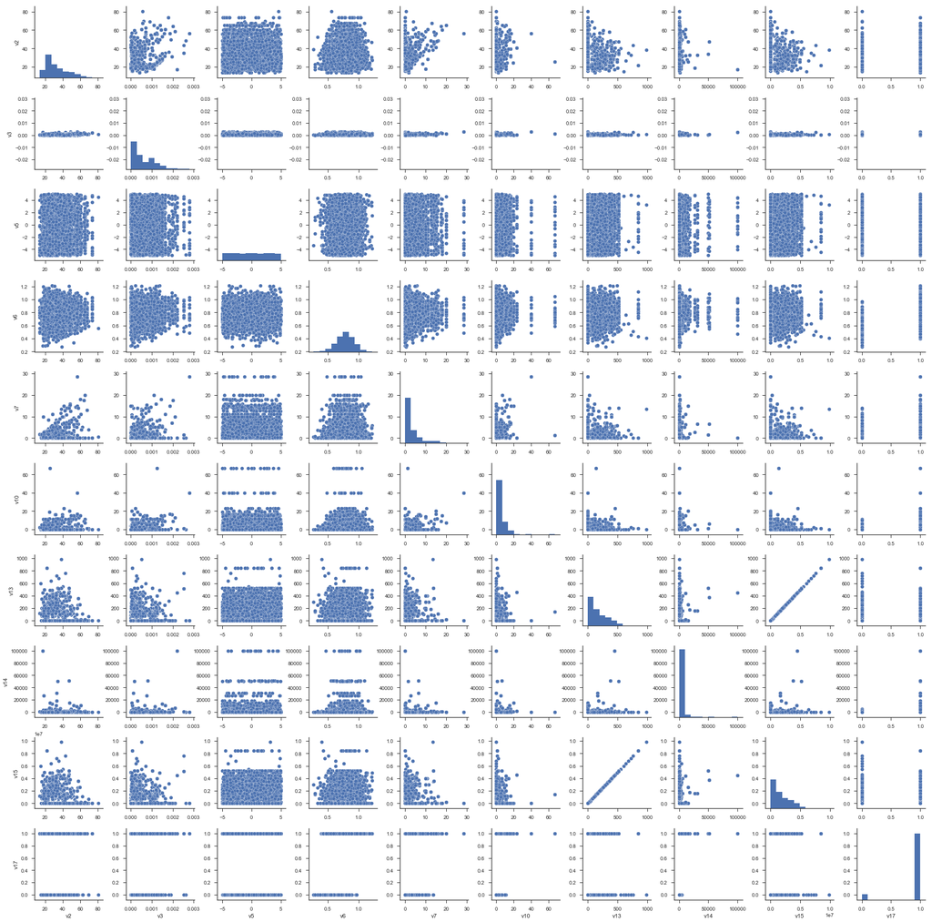

```python
sns.pairplot(trainSet)
```

#### Correlations

```python
trainSet.corr()
```

|  | v2 | v3 | v5 | v6 | v7 | v10 | v13 | v14 | v15 | v17 |
| --- | --- | --- | --- | --- | --- | --- | --- | --- | --- | --- |
| v2 | 1.000000 | 0.294274 | -0.013442 | 0.025070 | 0.539910 | 0.217339 | -0.157397 | -0.008037 | -0.157397 | 0.064766 |
| v3 | 0.294274 | 1.000000 | -0.015987 | 0.058895 | 0.331420 | 0.299295 | -0.279042 | 0.138755 | -0.279042 | 0.105042 |
| v5 | -0.013442 | -0.015987 | 1.000000 | -0.017247 | -0.006467 | -0.007988 | 0.042140 | 0.014675 | 0.042140 | 0.004410 |
| v6 | 0.025070 | 0.058895 | -0.017247 | 1.000000 | 0.042384 | 0.061648 | 0.004884 | 0.027728 | 0.004884 | 0.383127 |
| v7 | 0.539910 | 0.331420 | -0.006467 | 0.042384 | 1.000000 | 0.297524 | -0.215329 | -0.008237 | -0.215329 | 0.144585 |
| v10 | 0.217339 | 0.299295 | -0.007988 | 0.061648 | 0.297524 | 1.000000 | -0.152554 | -0.010901 | -0.152554 | 0.155626 |
| v13 | -0.157397 | -0.279042 | 0.042140 | 0.004884 | -0.215329 | -0.152554 | 1.000000 | 0.156229 | 1.000000 | -0.042424 |
| v14 | -0.008037 | 0.138755 | 0.014675 | 0.027728 | -0.008237 | -0.010901 | 0.156229 | 1.000000 | 0.156229 | 0.067963 |
| v15 | -0.157397 | -0.279042 | 0.042140 | 0.004884 | -0.215329 | -0.152554 | 1.000000 | 0.156229 | 1.000000 | -0.042424 |
| v17 | 0.064766 | 0.105042 | 0.004410 | 0.383127 | 0.144585 | 0.155626 | -0.042424 | 0.067963 | -0.042424 | 1.000000 |

The Pearson correlation values are fairly low mostly, but v13 and v15 are prefectly correlated. V15 is simply v13 * 10000. So, we can drop one of them.

```python
trainSet = trainSet.drop(['v15'], axis=1)
```

# Handle Categorical Encoding

```python
trainSet.head()
```

|  | v1 | v2 | v3 | v4 | v5 | v6 | v7 | v8 | v9 | v10 | v11 | v12 | v13 | v14 | v17 | classLabel |
| --- | --- | --- | --- | --- | --- | --- | --- | --- | --- | --- | --- | --- | --- | --- | --- | --- |
| 0 | a | 17.92 | 0.000054 | u | -0.840182 | 0.522883 | 1.750 | f | t | 1 | t | g | 80.0 | 5 | 0 | no. |
| 1 | b | 16.92 | 0.000034 | y | -2.159635 | 0.774187 | 0.290 | f | f | 0 | f | s | 200.0 | 0 | 0 | no. |
| 2 | b | 31.25 | 0.000112 | u | 1.750687 | 0.760363 | 0.000 | f | t | 1 | f | g | 96.0 | 19 | 0 | no. |
| 3 | a | 48.17 | 0.000133 | u | 4.174871 | 0.888963 | 0.335 | f | f | 0 | f | g | 0.0 | 120 | 0 | no. |
| 4 | b | 32.33 | 0.000350 | u | -3.785479 | 0.489024 | 0.500 | f | f | 0 | t | g | 232.0 | 0 | 0 | no. |

```python
trainSet_enc = pd.get_dummies(columns=['v1', 'v4', 'v8', 'v9', 'v11', 'v12'], data=trainSet, drop_first=True)
```

```python
trainSet_enc.head()
```

|  | v2 | v3 | v5 | v6 | v7 | v10 | v13 | v14 | v17 | classLabel | v1_b | v4_u | v4_y | v8_t | v9_t | v11_t | v12_p | v12_s |
| --- | --- | --- | --- | --- | --- | --- | --- | --- | --- | --- | --- | --- | --- | --- | --- | --- | --- | --- |
| 0 | 17.92 | 0.000054 | -0.840182 | 0.522883 | 1.750 | 1 | 80.0 | 5 | 0 | no. | 0 | 1 | 0 | 0 | 1 | 1 | 0 | 0 |
| 1 | 16.92 | 0.000034 | -2.159635 | 0.774187 | 0.290 | 0 | 200.0 | 0 | 0 | no. | 1 | 0 | 1 | 0 | 0 | 0 | 0 | 1 |
| 2 | 31.25 | 0.000112 | 1.750687 | 0.760363 | 0.000 | 1 | 96.0 | 19 | 0 | no. | 1 | 1 | 0 | 0 | 1 | 0 | 0 | 0 |
| 3 | 48.17 | 0.000133 | 4.174871 | 0.888963 | 0.335 | 0 | 0.0 | 120 | 0 | no. | 0 | 1 | 0 | 0 | 0 | 0 | 0 | 0 |
| 4 | 32.33 | 0.000350 | -3.785479 | 0.489024 | 0.500 | 0 | 232.0 | 0 | 0 | no. | 1 | 1 | 0 | 0 | 0 | 1 | 0 | 0 |

**Encoding Y:** In column classLabel encoding the minority class - No - as 1 and majority class - Yes - as 0

```python
trainSet_enc['classLabel'] = pd.to_numeric(trainSet_enc.classLabel.str.replace('yes.', '0').str.replace('no.', '1'))
```

```python
trainSet_enc.head()
```

|  | v2 | v3 | v5 | v6 | v7 | v10 | v13 | v14 | v17 | classLabel | v1_b | v4_u | v4_y | v8_t | v9_t | v11_t | v12_p | v12_s |
| --- | --- | --- | --- | --- | --- | --- | --- | --- | --- | --- | --- | --- | --- | --- | --- | --- | --- | --- |
| 0 | 17.92 | 0.000054 | -0.840182 | 0.522883 | 1.750 | 1 | 80.0 | 5 | 0 | 1 | 0 | 1 | 0 | 0 | 1 | 1 | 0 | 0 |
| 1 | 16.92 | 0.000034 | -2.159635 | 0.774187 | 0.290 | 0 | 200.0 | 0 | 0 | 1 | 1 | 0 | 1 | 0 | 0 | 0 | 0 | 1 |
| 2 | 31.25 | 0.000112 | 1.750687 | 0.760363 | 0.000 | 1 | 96.0 | 19 | 0 | 1 | 1 | 1 | 0 | 0 | 1 | 0 | 0 | 0 |
| 3 | 48.17 | 0.000133 | 4.174871 | 0.888963 | 0.335 | 0 | 0.0 | 120 | 0 | 1 | 0 | 1 | 0 | 0 | 0 | 0 | 0 | 0 |
| 4 | 32.33 | 0.000350 | -3.785479 | 0.489024 | 0.500 | 0 | 232.0 | 0 | 0 | 1 | 1 | 1 | 0 | 0 | 0 | 1 | 0 | 0 |

```python
trainSet_enc.classLabel.value_counts()
```

```
0    3328
1     269
Name: classLabel, dtype: int64
```

```python
trainSet[trainSet['v17'] != trainSet['classLabel']].shape
```

```
(3597, 16)
```

[figure not shown]

```python
sns.pairplot(trainSet)
```

**Observations**

- V17 is the numeric encoded version of classLabel, so will have to removed from the X data
- V2, V3, V7, V10, and V13 are all right skewed, so there *might be* some benefit from a log transformation to make it more normal for certain classifiers

## Split into X and Y

```python
trY = trainSet_enc.classLabel
trX = trainSet_enc.drop('classLabel', axis=1)
```

```python
trX.head()
```

|  | v2 | v3 | v5 | v6 | v7 | v10 | v13 | v14 | v17 | v1_b | v4_u | v4_y | v8_t | v9_t | v11_t | v12_p | v12_s |
| --- | --- | --- | --- | --- | --- | --- | --- | --- | --- | --- | --- | --- | --- | --- | --- | --- | --- |
| 0 | 17.92 | 0.000054 | -0.840182 | 0.522883 | 1.750 | 1 | 80.0 | 5 | 0 | 0 | 1 | 0 | 0 | 1 | 1 | 0 | 0 |
| 1 | 16.92 | 0.000034 | -2.159635 | 0.774187 | 0.290 | 0 | 200.0 | 0 | 0 | 1 | 0 | 1 | 0 | 0 | 0 | 0 | 1 |
| 2 | 31.25 | 0.000112 | 1.750687 | 0.760363 | 0.000 | 1 | 96.0 | 19 | 0 | 1 | 1 | 0 | 0 | 1 | 0 | 0 | 0 |
| 3 | 48.17 | 0.000133 | 4.174871 | 0.888963 | 0.335 | 0 | 0.0 | 120 | 0 | 0 | 1 | 0 | 0 | 0 | 0 | 0 | 0 |
| 4 | 32.33 | 0.000350 | -3.785479 | 0.489024 | 0.500 | 0 | 232.0 | 0 | 0 | 1 | 1 | 0 | 0 | 0 | 1 | 0 | 0 |

## Base performance

Since the dataset is highly unbalanced, I just wanted to see what the scores would look like if we just returned Yes for every row

```python
y_pred_always_yes = np.zeros(trX.shape[0])
```

```python
tn, fp, fn, tp = confusion_matrix(y_true=trY_enc, y_pred=y_pred_always_yes).ravel()
print("tp, fp, fn, tn:", tp, fp, fn, tn)
print("tp, fp, fn, tn as %s:", np.array([tp, fp, fn, tn])*100/trX.shape[0])
print("F1 Score:", f1_score(y_true=trY_enc, y_pred=y_pred_always_yes))
print("Accuracy:", accuracy_score(y_true=trY_enc, y_pred=y_pred_always_yes))
```

```
tp, fp, fn, tn: 0 0 269 3328
tp, fp, fn, tn as %s: [  0.           0.           7.47845427  92.52154573]
F1 Score: 0.0
Accuracy: 0.925215457326
```

```
Confusion matrix, without normalization
[[3328    0]
 [ 269    0]]
```

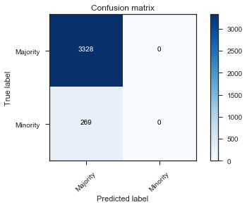

```python
helperFunctions.plot_confusion_matrix(confusion_matrix(y_true=trY_enc, y_pred=y_pred_always_yes), classes=["Majority", "Minority"])
```